# Глава 3. Линейная регрессия.

Литвинцев И.С

21 августа 2018 г

## Задание 10.

This question should be answered using the Carseats data set.

#### (a) Fit a multiple regression model to predict `Sales` using `Price`, `Urban`, and `US`.

Для начала опишем используемые переменные.

1. `Sales` - Unit sales (in thousands) at each location.
2. `Price` - Price company charges for car seats at each site.
3. `Urban` - A factor with levels No and Yes to indicate whether the store is in an urban or rural location.
4. `US` - A factor with levels No and Yes to indicate whether the store is in the US or not.

```r
head(Carseats)
```

```
##   Sales CompPrice Income Advertising Population Price ShelveLoc Age
## 1  9.50       138     73          11        276   120       Bad  42
## 2 11.22       111     48          16        260    83      Good  65
## 3 10.06       113     35          10        269    80    Medium  59
## 4  7.40       117    100           4        466    97    Medium  55
## 5  4.15       141     64           3        340   128       Bad  38
## 6 10.81       124    113          13        501    72       Bad  78
##   Education Urban  US
## 1        17   Yes Yes
## 2        10   Yes Yes
## 3        12   Yes Yes
## 4        14   Yes Yes
## 5        13   Yes  No
## 6        16    No Yes
```

```r
attach(Carseats)

lm.fit <- lm(Sales ~ Price + Urban + US, Carseats)
summary(lm.fit)
```

```
##
## Call:
## lm(formula = Sales ~ Price + Urban + US, data = Carseats)
##
## Residuals:
##     Min      1Q  Median      3Q     Max
## -6.9206 -1.6220 -0.0564  1.5786  7.0581
##
## Coefficients:
##              Estimate Std. Error t value Pr(>|t|)
## (Intercept) 13.043469   0.651012  20.036  < 2e-16 ***
## Price       -0.054459   0.005242 -10.389  < 2e-16 ***
## UrbanYes    -0.021916   0.271650  -0.081    0.936
## USYes        1.200573   0.259042   4.635 4.86e-06 ***
## ---
## Signif. codes:  0 '***' 0.001 '**' 0.01 '*' 0.05 '.' 0.1 ' ' 1
##
## Residual standard error: 2.472 on 396 degrees of freedom
## Multiple R-squared:  0.2393, Adjusted R-squared:  0.2335
## F-statistic: 41.52 on 3 and 396 DF,  p-value: < 2.2e-16
```

#### (b) Provide an interpretation of each coefficient in the model. Becareful—some of the variables in the model are qualitative!

Коэффициент при предикторе `Price` равен $-0.054$. Это можно проинтерпретировать, как среднее количество нереализованных детских кресел в случае увеличения цены на один пункт. Т.е. при увеличении цены детского кресла на 1 доллар компания в среднем будет реализовывать на 54 кресла меньше.

Коэффициент `Intercept` равный $13.043$ интерпретируется, как средний прирост в продажах кресел среди магазинов, находящихся в пригородах за пределами США. Т.е. в среднем эти магазины реализуют около 13043 штук кресел.

Коэффициент при dummy переменной `UrbanYes` равен $-0.022$ и интерпретируется, как среднее уменьшение продаж кресел в магазинах, расположенных в городах за пределами США, по потношению к показателям продаж магазинов, расположенных в пригородах за пределами США. Т.е. в среднем на 22 кресла объем продаж в этих магазинах уменьшается.

Коэффициент при dummy переменной `USYes` равен $1.200$ и интерпретируется, как среднее увеличение продаж кресел в магазинах, расположенных в пригородах США, по потношению к показателям продаж магазинов, расположенных в пригородах за пределами США. Т.е. в среднем на 1200 кресел объем продаж в этих магазинах увеличивается.

#### (c) Write out the model in equation form, being careful to handle the qualitative variables properly.

Посмотрим на кодировку dummy переменных `UrbanYes` и `USYes` (хотя это можно понять из названий этих переменных).

```r
contrasts(Carseats$US)
```

```
##     Yes
## No    0
## Yes   1
```

```r
contrasts(Carseats$Urban)
```

```
##     Yes
## No    0
## Yes   1
```

Выпишем уравнение регресии для i-го наблюдения.

$$\textbf{Sales} = \beta_0 + \beta_1 \times \textbf{Price} + \beta_2 \times \textbf{USYes} +\beta_3 \times \textbf{UrbanYes} + \varepsilon.$$
Подставив значения dummy переменных, получим:

$$\textbf{Sales} = \beta_1 \times \textbf{Price} + \begin{cases} \beta_0 + \beta_2 + \beta_3 + \varepsilon, & \mbox{если магазин находится в городе США} \\ \beta_0 +\beta_2 + \varepsilon, & \mbox{если магазин находится в пригороде США} \\ \beta_0 + \beta_3 + \varepsilon, & \mbox{если магазин находится в городе за пределами США} \\
\beta_0 + \varepsilon, & \mbox{если магазин находится в пригороде за пределами США}
\end{cases}$$

#### (d) For which of the predictors can you reject the null hypothesis $H_0: \beta_j = 0$?

Для удобства выведем Summary еще раз.

```r
summary(lm.fit)
```

```
##
## Call:
## lm(formula = Sales ~ Price + Urban + US, data = Carseats)
##
## Residuals:
##     Min      1Q  Median      3Q     Max
## -6.9206 -1.6220 -0.0564  1.5786  7.0581
##
## Coefficients:
##              Estimate Std. Error t value Pr(>|t|)
## (Intercept) 13.043469   0.651012  20.036  < 2e-16 ***
## Price       -0.054459   0.005242 -10.389  < 2e-16 ***
## UrbanYes    -0.021916   0.271650  -0.081    0.936
## USYes        1.200573   0.259042   4.635 4.86e-06 ***
## ---
## Signif. codes:  0 '***' 0.001 '**' 0.01 '*' 0.05 '.' 0.1 ' ' 1
##
## Residual standard error: 2.472 on 396 degrees of freedom
## Multiple R-squared:  0.2393, Adjusted R-squared:  0.2335
## F-statistic: 41.52 on 3 and 396 DF,  p-value: < 2.2e-16
```

Если за уровень значимости принять стандартное значение $\alpha = 0.05$, то глядя на p-value для наших предикторов, приходим к очевидному выводу, что предиктор `UrbanYes` незначим, а остальные значимы.

#### (e) On the basis of your response to the previous question, fit a smaller model that only uses the predictors for which there is evidence of association with the outcome.

Итак, исключая незначимый предиктор `Urban`, получим модель:

```r
lm.fit <- lm(Sales ~ Price + US, Carseats)
summary(lm.fit)
```

```
##
## Call:
## lm(formula = Sales ~ Price + US, data = Carseats)
##
## Residuals:
##     Min      1Q  Median      3Q     Max
## -6.9269 -1.6286 -0.0574  1.5766  7.0515
##
## Coefficients:
##             Estimate Std. Error t value Pr(>|t|)
## (Intercept) 13.03079    0.63098  20.652  < 2e-16 ***
## Price       -0.05448    0.00523 -10.416  < 2e-16 ***
## USYes        1.19964    0.25846   4.641 4.71e-06 ***
## ---
## Signif. codes:  0 '***' 0.001 '**' 0.01 '*' 0.05 '.' 0.1 ' ' 1
##
## Residual standard error: 2.469 on 397 degrees of freedom
## Multiple R-squared:  0.2393, Adjusted R-squared:  0.2354
## F-statistic: 62.43 on 2 and 397 DF,  p-value: < 2.2e-16
```

#### (f) How well do the models in (a) and (e) fit the data?

Чтобы ответить на этот вопрос, обратим внимание на **RSE** и **Adjusted R-squared**. Из таблицы делаем вывод, что **RSE** для модели (a) больше, чем для модели (e). А также значение **Adjusted R-squared** модели (a) меньше, чем (e). Т.е. модель (e) чуть лучше объясняет разброс в данных, чем модель (а).

|  | Модель (a) | Модель (e) |
| --- | --- | --- |
| **RSE** | 2.472 | 2.469 |
| **R^2 adjusted** | 0.2335 | 0.2354 |

Однако заметим, что значения **Adjusted R-squared** довольно низки в обоих случаях. Это должно навести нас на мысль, что обе модели линейной регрессии возможно недостаточно хорошо соответствуют данным, либо дисперсия в данных слишком большая.

#### (g) Using the model from (e), obtain 95% confidence intervals for the coefficient(s).

```r
confint(lm.fit, level = 0.95)
```

```
##                   2.5 %      97.5 %
## (Intercept) 11.79032020 14.27126531
## Price       -0.06475984 -0.04419543
## USYes        0.69151957  1.70776632
```

#### (h) Is there evidence of outliers or high leverage observations in the model from (e)?

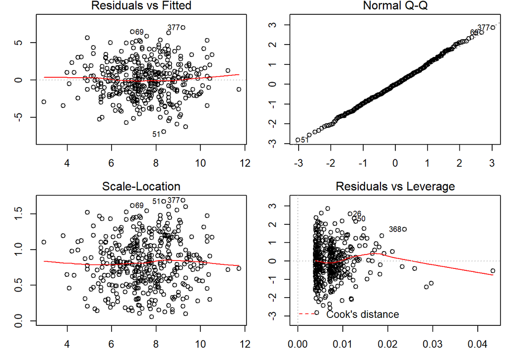

```r
{par(mfrow=c(2,2), mai=c(0.5,0.5,0.2,0.1))
plot(lm.fit)}
```

```r
#plot(hatvalues(lm.fit), sqrt(abs(rstudent(lm.fit))))
#which.max(hatvalues(lm.fit))
#Carseats[43, c("Sales", "Price")]
```

Что можно сказать, глядя на эти графики? Во-первых, по графику **Residuals vs Fitted** видим, что нет паттернов и зависимость действительно похожа на линейную. Также отметим постоянную высокую дисперсию, которую мы предполагали увидеть, глядя на низкое значение **Adjusted R-squared** статистики.

Судя по графикам **Scale-Location** и **Residuals vs Leverage**, явных аутлайеров нет (т.к. все значение Standardized residuals на графике **Residuals vs Leverage** принадлежат отрезку [-3,3]). Точка с максимальным значением leverage чуть больше 0.04 подозрительна на high leverage point, но, вообще говоря, у нее не достаточно высокое значение уровня leverage - чуть больше 0.04 при среднем значениие leverage всех точек равным $\frac{p+1}{n} = \frac{3}{400} = 0.0075$. Поэтому оставим ее.

#### Построим график продаж в зависимости от цены и местнахождения магазинов.

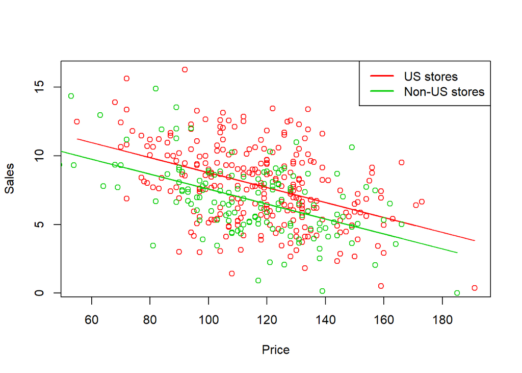

```r
ind <- Carseats$US == "Yes"
{plot(Price[ind], Sales[ind], col=2, xlab = "Price", ylab = "Sales")+
  lines(Price[ind], fitted(lm.fit)[ind], col=2)+
  points(Price[!ind], Sales[!ind], col=3)+
  lines(Price[!ind], fitted(lm.fit)[!ind], col=3)
  legend("topright", legend = c("US stores", "Non-US stores"), col=c(2,3),lty=1, lwd=2)
}
```

```r
detach(Carseats)
```